# wordProphet

Panayiotis L.  
03 Oct 2020

Coursera Data Science Specialization  
Capstone Project  
Johns Hopkins University

# **Objective**

This presentation features the wordProphet app including an introduction to the application, user interface and details about the text prediction algorithm.

The wordProphet app is located at:

- https://ghost-8d.shinyapps.io/wordProphet_v1/

The source code can be found on GitHub:

- https://github.com/Ghost-8D/data_science_capstone/tree/master/wordProphet

# **Shiny App**

WordProphet is a Shiny app that takes as input text from a user and attempts to predict the next word(s) using a text prediction algorithm.

The application uses an n-gram algorithm to suggest the next word in a sentence. An **n-gram** is a contiguous sequence of *n* words from a given sequence of text.

To build the predictive text model, a large corpus of blogs, news and twitter data was used. N-grams were extracted from the corpus and then used to build the predictive text model.

Various methods were used in order to improve the speed and accuracy of the predictor, using natural language processing and text mining techniques.

# **The Predictive Text Model**

The predictive text model was built from a sample of 800,000 lines extracted from the large corpus of blogs, news and twitter data.

The sample data was then tokenized and cleaned using the **tm** package and a number of regular expressions using the **gsub** function. As part of the cleaning process the data was converted to lowercase, removed all non-ascii characters, URLs, email addresses, Twitter handles, hash tags, ordinal numbers, profane words, punctuation and whitespace. The data was then split into tokens (n-grams).

As text is entered by the user, the algorithm iterates from longest n-gram (4-gram) to shortest (2-gram) to detect a match. The predicted next word is considered using the longest, most frequent matching n-gram. The algorithm makes use of a simple back-off strategy.

# **Application User Interface**

The predicted next word will be displayed when the app detects that the user has finished typing one or more words. When entering text, please allow a few seconds for the output to appear. Use the slider tool to select up to three next word predictions. The top prediction will be shown first followed by the second and third likely next words. Click the image below for a larger view of the user interface.

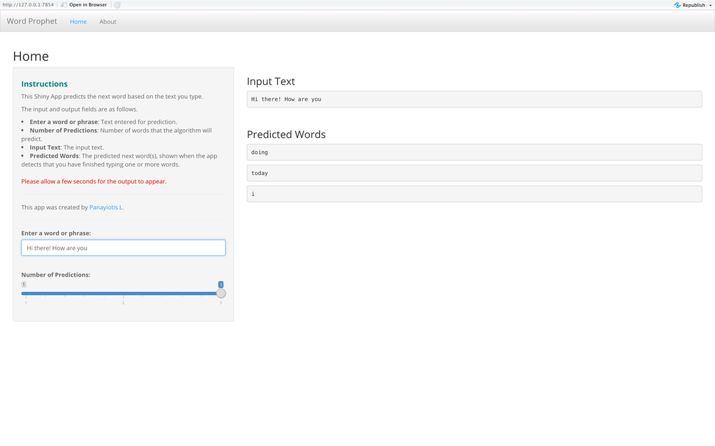